# Data Acquisition - APIs

Jack Davis

2024-03-05

# Packages

```r
library(ggplot2)
library(dplyr)
```

# Motivation

Complex events (e.g. winning a baseball game) are composed of simple events (e.g., getting a base hit). Sometimes finding a closed form solution for a complex event is impractical or very hard.

Take the game Borel, for instance. It has a collection of experiments near a 50/50 chance for players to predict. For example:

Experiment 001: Roll d6, d6, d6, d6, d10, and d30. Will you roll 5 or more unique numbers?

# Borel

finding the distribution of the number of uniques for identical dice isn’t hard.

(e.g. Pr(3 or more uniques) = 6/6 * 5/6 * 4/6 * 6/6)

But once you introduce two additional dice of different numbers of sides, the computation gets too complicated for a casual tabletop game. That’s the point though, if you enjoy math puzzles, or reading chance magazine or anything by Martin Gardner, then the experiments are deep enough to have nerd gravity. If you just want to play a short casual game with dice and more variety than Yahtzee, then you still have a shot at winning with thinking too hard.

You’re not supposed to prepare, it sort of ruins the game. You can’t have “Ruin” without “R”.

# Borel

First, let’s make a function to roll dice. Not a perfectly efficient one, but a readable, informative one.

```r
random.dice = function(dice_used = c(6,6,6,6,10,20,30), Nrolls=100000, seed=NA)
{
if(!is.na(seed)){set.seed(seed)}

Ndice = length(dice_used)
rollmat = matrix(NA, nrow=Nrolls, ncol=Ndice)

for(k in 1:Ndice)
{
rollmat[,k] = sample(1:dice_used[k], size=Nrolls, replace=T)
}

return(rollmat)
}

# Test: Outputs a 10 x 7 matrix with 10 random rolls of 4d6, d10, d20, d30
random.dice(Nrolls=10)
```

```
##       [,1] [,2] [,3] [,4] [,5] [,6] [,7]
##  [1,]    5    2    6    3    1    6   18
##  [2,]    5    1    4    2    5   13   13
##  [3,]    1    5    2    1    3   20   26
##  [4,]    3    4    2    6    2   12   14
##  [5,]    4    4    2    2    7   15   24
##  [6,]    1    2    3    2    4    3   21
##  [7,]    3    6    6    2    9    2   22
##  [8,]    4    5    5    6    6   12   24
##  [9,]    6    5    2    3    5   14    3
## [10,]    1    4    3    4    7    1   24
```

# Borel

A lot of these experiments can be solved the same way: Generate some rolls, and apply a function row-by-row to check of each row would be a ‘success’ or not. What changes each time are the generator inputs and the function being applied.

In this first experiment, we want to know the number of unique numbers from each roll of the experiment.

```r
count.uniques = function(roll)
{
    output = length(unique(roll))
}

Nrolls = 100000
rollmat = random.dice(dice_used = c(6,6,6,6,10,30), Nrolls=Nrolls, seed=12345)
Nuniques = apply(rollmat, 1, count.uniques)
```

# Borel

```r
# The distribution
table(Nuniques)  / nrow(rollmat)
```

```
## Nuniques
##       1       2       3       4       5       6
## 0.00001 0.00285 0.06233 0.33397 0.46277 0.13807
```

# This is Monte Carlo

So what have we done here?

Found the probabilities of small elements. (e.g. single die rolls).

Generate the results of the complex event and record.

Repeat step 2 thousands of times, get the proportion of times that the criterion is met and/or that the complex event happened.

# Cricket is..

Cricket is a discrete event game like baseball each ball thrown can result in 0, 1, 2, 3 (rare), 4, 5 (rare), or 6 runs or an out/wicket.

In the Twenty20 format, up to 120 balls (pitches) are thrown per side, as long as they are within the equivalent of a strike zone. The value of interest is the total runs scored before either 120 balls are thrown or 10 wickets/outs are taken.

Like baseball, there is a batsman (batter) and a bowler (pitcher), and a collection of fielders. There are only 2 bases and getting from one base to the other is a run.

Here’s our dataset. One row is one ball thrown. There are about 800 matches here, totalling over 160,000 balls thrown.

# Our data

```r
gamelog = read.csv("Gamelog T20I and IPL 2015-11-16.csv")
head(gamelog)
```

```
##   Format MatchNo TeamBowling TeamBatting Inning Over Ball Bowler BowlerID
## 1   T20I      33         AUS          BD      1    0    1  B Lee       17
## 2   T20I      33         AUS          BD      1    0    2  B Lee       17
## 3   T20I      33         AUS          BD      1    0    3  B Lee       17
## 4   T20I      33         AUS          BD      1    0    4  B Lee       17
## 5   T20I      33         AUS          BD      1    0    4  B Lee       17
## 6   T20I      33         AUS          BD      1    0    5  B Lee       17
##       Batsman BatsmanID Fielder FielderID Outcome NumOutcome BallType
## 1 Tamim Iqbal      1041                NA      no          0      run
## 2 Tamim Iqbal      1041                NA      no          0      run
## 3 Tamim Iqbal      1041                NA      no          0      run
## 4 Tamim Iqbal      1041                NA       1          1     wide
## 5 Tamim Iqbal      1041                NA      no          0      run
## 6 Tamim Iqbal      1041                NA      no          0      run
##   NumBallType  Notes
```

[output cut: 20 more lines]

```r
nrow(gamelog)
```

```
## [1] 168966
```

```r
# Removing two incorrect cases and two seven runs
# Also looking only at the first half of the game
gamelog = subset(gamelog, NumOutcome < 7 & Inning == 1 & Wickets < 10)
```

# Our data

We can estimate the probabilities of these events (0,1,2,3,4,5,6,out) a variety of ways.

- The global average rate for the league
- The personal average rate for batters.
- The average of batter and bowler rate.
- Game situation dependent.

Example: If there are only a few balls left and many wickets remaining, then wickets, fours, and sixes become relatively more common.

```r
# Num ball type 0 is a legally bowled ball
# The others don't count towards the 120
table(gamelog$NumBallType)
```

```
##
##     0     1     2     3     4
## 85910   403  2676   303  1613
```

```r
table(gamelog$NumBallType)/nrow(gamelog)
```

```
##
##           0           1           2           3           4
## 0.945052527 0.004433199 0.029437325 0.003333150 0.017743798
```

So the global chance of a no-ball is about 5.5%

# Our data

Ignoring player and situation effects we can simulate a game between two average teams.

```r
# -1 is a wicket, 0-6 are runs without a wicket
table(gamelog$NumOutcome)
```

```
##
##    -1     0     1     2     3     4     5     6
##  4380 27827 37556  6679   434  9964   163  3902
```

```r
table(gamelog$NumOutcome) / nrow(gamelog)
```

```
##
##          -1           0           1           2           3           4
## 0.048182168 0.306110775 0.413134591 0.073472306 0.004774215 0.109608932
##           5           6
## 0.001793081 0.042923932
```

```r
# We will use this as our outcome chance.
outcome_chance_naive = as.numeric(table(gamelog$NumOutcome)) / nrow(gamelog)
```

# Simulation

```r
set.seed(8675309)
Nsims = 5000
allsims_runs = rep(NA, Nsims)
allsims_outs = rep(NA, Nsims)
allsims_runs_batter = matrix(NA, nrow=Nsims, ncol=10)

for(simcount in 1:Nsims)
{
  runs_this_batter = rep(0,10)
  runs = 0
  outs = 0
  balls_thrown = 0
  while(balls_thrown < 120 & outs < 10)
  {

      noball_chance = 0.0547
      outcome_chance = outcome_chance_naive
                      # W, 0, 1, 2, 3, 4, 5, 6

      if(runif(1) > noball_chance){balls_thrown = balls_thrown + 1}

      outcome_idx = sample(1:8, 1, prob=outcome_chance)
      runs = runs + c(0,0,1:6)[outcome_idx]
      outs = outs + c(1,0,0,0,0,0,0,0)[outcome_idx]

      if(outs < 10)
      {
          runs_this_batter[outs+1] = runs_this_batter[outs+1] + c(0,0,1:6)[outcome_idx]
      }
  }

allsims_runs[simcount] = runs
allsims_outs[simcount] = outs
allsims_runs_batter[simcount, ] = runs_this_batter

}
```

# Results

The distribution of runs would be this for the first team up…

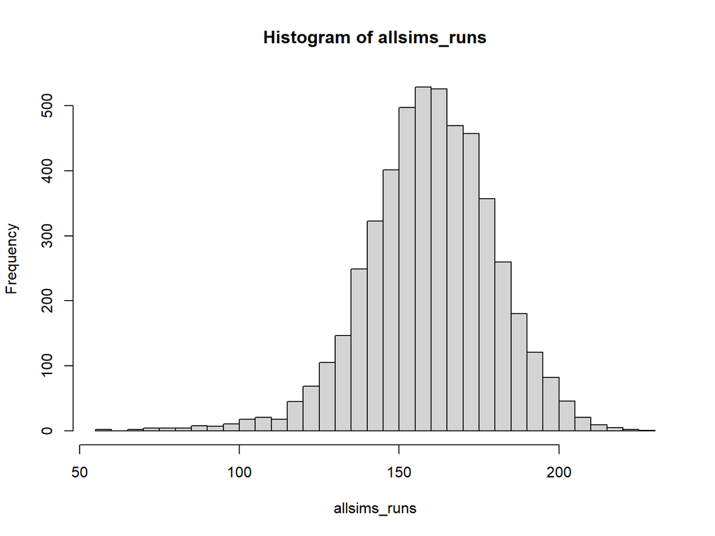

```r
hist(allsims_runs, n=50)
```

# Results

The distribution of wickets taken would be this…

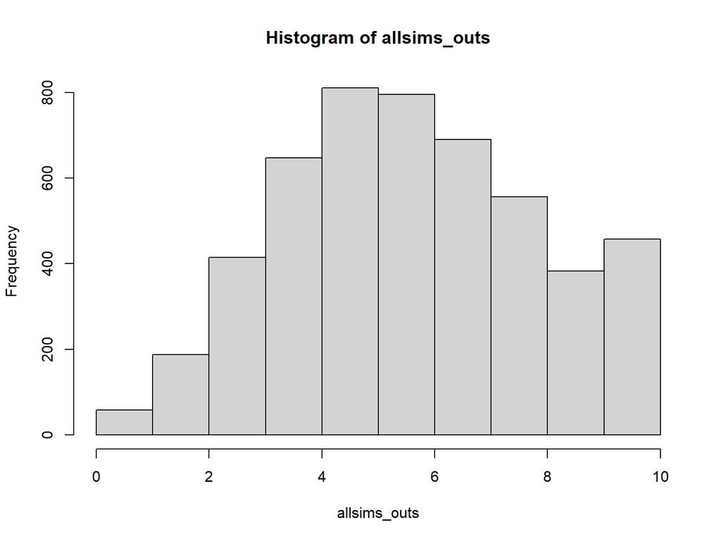

```r
hist(allsims_outs, n=10)
```

# Results

The average runs scores by the first, second, third batter and so on.

```r
runmeans = apply(allsims_runs_batter, 2, mean)
runmeans
```

```
##  [1] 26.5638 25.6356 24.9968 23.2500 19.5916 15.3666 11.0064  7.1252  4.3398
## [10]  2.4460
```

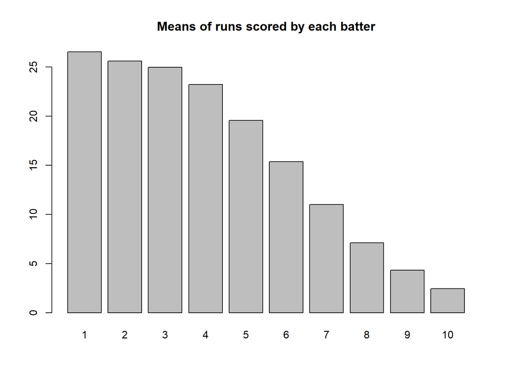

```r
##  [1] 26.6762 25.2806 25.1246 23.3094 19.2730 15.6012 11.0130  7.1430  4.3498
## [10]  2.4492

barplot(runmeans, main="Means of runs scored by each batter",
        names.arg = 1:10)
```

# Results

The distribution of both would be this…

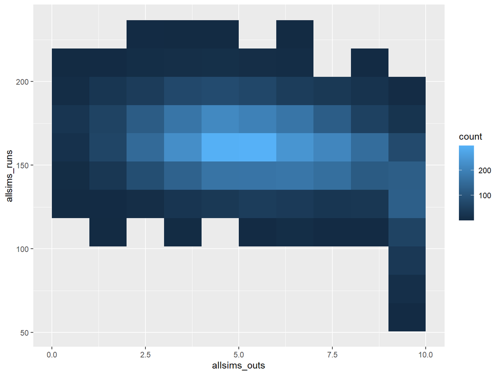

```r
ro = data.frame(allsims_runs, allsims_outs)

ggplot(ro, aes(x=allsims_outs, y=allsims_runs) ) +
  geom_bin2d(bins=10)
```

# Simulation 2

Now let’s see about getting a better estimate for the outcome probabilities. These depend on many things, but let’s focus on the number of balls thrown. Balls are put into groups of six called overs. There are different rules for fielding during different overs, and these should be reflected in the proportion of each event that happens during that over.

```r
table(gamelog$Over, gamelog$NumOutcome)
```

```
##
##        -1    0    1    2    3    4    5    6
##   0   143 2502 1299  213   37  526   21   62
##   1   177 2297 1320  212   43  625   13   91
##   2   180 1982 1352  241   30  736   12  150
##   3   187 1898 1492  212   31  705   10  160
##   4   178 1863 1449  206   32  765    6  163
##   5   200 1779 1560  236   19  692    8  173
##   6   164 1577 2131  277   18  331   12  105
##   7   144 1442 2128  296   21  383   10  167
##   8   190 1356 2122  328   24  390    4  145
##   9   158 1299 2214  338   14  356    4  174
##   10  193 1249 2167  352   16  380    5  165
##   11  183 1195 2172  358   24  387    7  189
##   12  190 1208 2139  346   12  360    5  225
##   13  176 1127 2184  370   11  409    6  189
##   14  234 1097 2066  372   20  449    9  229
##   15  223  964 2115  420   15  434    4  250
##   16  257  899 2081  414    8  510    6  261
##   17  348  829 1970  452   18  489    7  313
##   18  365  758 1891  451   15  523    3  331
##   19  490  506 1704  585   26  514   11  360
```

# Simulation 2

For example, wickets and sixes are much more common near the end of a team’s side. Also, fours are much more common during the first six overs.

With prop.table we can convert these into event probabilties.

```r
tab = table(gamelog$Over, gamelog$NumOutcome)
outcome_chance_over = as.matrix(prop.table(tab, 1))

round(prop.table(tab, 1), 3)
```

```
##
##         -1     0     1     2     3     4     5     6
##   0  0.030 0.521 0.270 0.044 0.008 0.110 0.004 0.013
##   1  0.037 0.481 0.276 0.044 0.009 0.131 0.003 0.019
##   2  0.038 0.423 0.289 0.051 0.006 0.157 0.003 0.032
##   3  0.040 0.404 0.318 0.045 0.007 0.150 0.002 0.034
##   4  0.038 0.400 0.311 0.044 0.007 0.164 0.001 0.035
##   5  0.043 0.381 0.334 0.051 0.004 0.148 0.002 0.037
##   6  0.036 0.342 0.462 0.060 0.004 0.072 0.003 0.023
##   7  0.031 0.314 0.464 0.064 0.005 0.083 0.002 0.036
##   8  0.042 0.297 0.465 0.072 0.005 0.086 0.001 0.032
##   9  0.035 0.285 0.486 0.074 0.003 0.078 0.001 0.038
##   10 0.043 0.276 0.479 0.078 0.004 0.084 0.001 0.036
##   11 0.041 0.265 0.481 0.079 0.005 0.086 0.002 0.042
##   12 0.042 0.269 0.477 0.077 0.003 0.080 0.001 0.050
##   13 0.039 0.252 0.488 0.083 0.002 0.091 0.001 0.042
##   14 0.052 0.245 0.462 0.083 0.004 0.100 0.002 0.051
##   15 0.050 0.218 0.478 0.095 0.003 0.098 0.001 0.056
##   16 0.058 0.203 0.469 0.093 0.002 0.115 0.001 0.059
##   17 0.079 0.187 0.445 0.102 0.004 0.110 0.002 0.071
##   18 0.084 0.175 0.436 0.104 0.003 0.121 0.001 0.076
##   19 0.117 0.121 0.406 0.139 0.006 0.122 0.003 0.086
```

# Simulation 2

Now let’s modify our simulator to account for overs and see the output again.

```r
set.seed(8675309)
Nsims = 5000
allsims_runs = rep(NA, Nsims)
allsims_outs = rep(NA, Nsims)
allsims_runs_batter = matrix(NA, nrow=Nsims, ncol=10)
allsims_runs_over = matrix(NA, nrow=Nsims, ncol=20)

for(simcount in 1:Nsims)
{
  runs_this_batter = rep(0,10)
  runs_this_over = rep(0,20)
  runs = 0
  outs = 0
  balls_thrown = 0
  while(balls_thrown < 120 & outs < 10)
  {
      over = ceiling((balls_thrown + 1) / 6)
      noball_chance = 0.0547
      #outcome_chance = outcome_chance_naive
      outcome_chance = outcome_chance_over[over,]
                      # W, 0, 1, 2, 3, 4, 5, 6

      if(runif(1) > noball_chance){balls_thrown = balls_thrown + 1}

      outcome_idx = sample(1:8, 1, prob=outcome_chance)
      runs = runs + c(0,0,1:6)[outcome_idx]
      outs = outs + c(1,0,0,0,0,0,0,0)[outcome_idx]

      if(outs < 10)
      {
          runs_this_batter[outs+1] = runs_this_batter[outs+1] + c(0,0,1:6)[outcome_idx]
      }

      runs_this_over[over] = runs_this_over[over] + c(0,0,1:6)[outcome_idx]
  }

allsims_runs[simcount] = runs
allsims_outs[simcount] = outs
allsims_runs_batter[simcount, ] = runs_this_batter
allsims_runs_over[simcount, ] = runs_this_over

}
```

# Results 2

The distribution of runs would be this for the first team up…

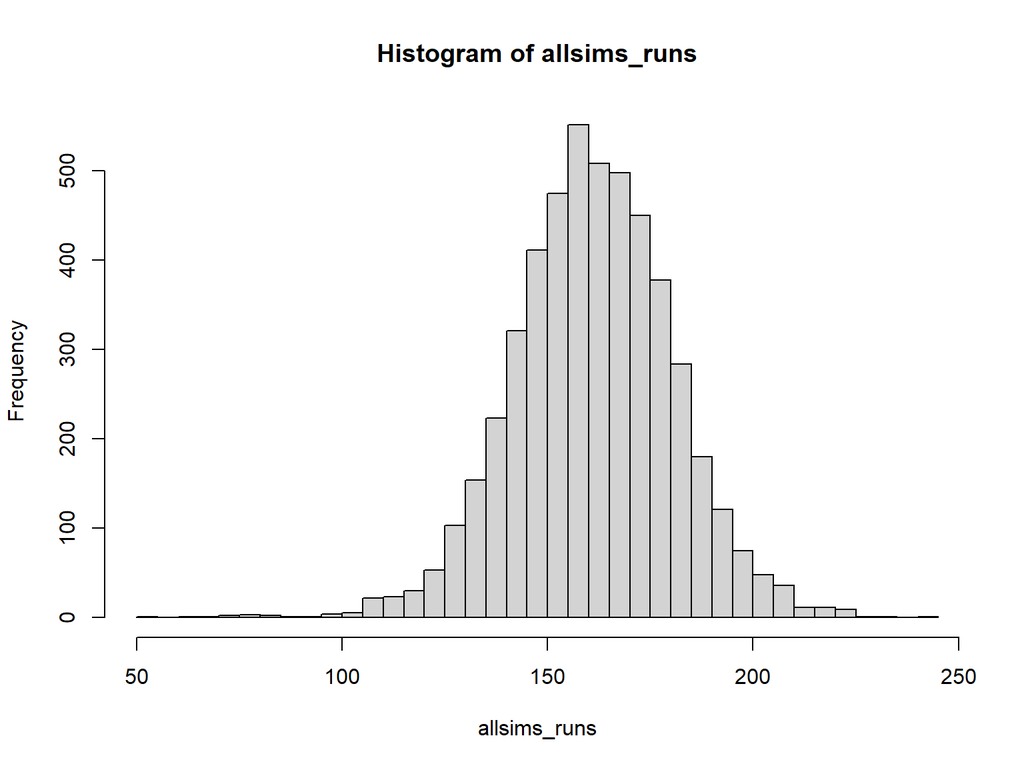

```r
hist(allsims_runs, n=50)
```

# Results 2

The distribution of wickets taken would be this…

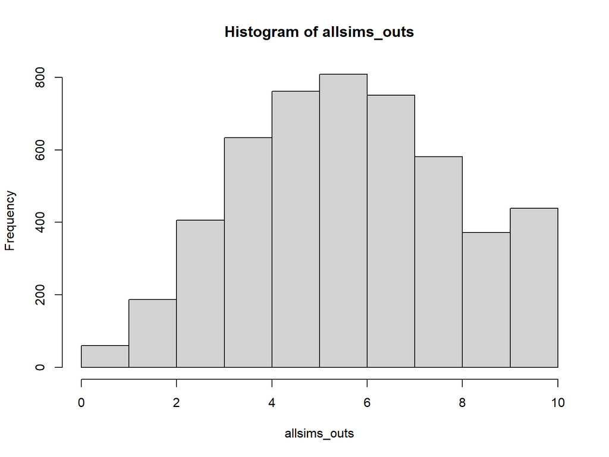

```r
hist(allsims_outs, n=10)
```

# Results 2

The average runs scores by the first, second, third batter and so on.

```r
runmeans2 = apply(allsims_runs_batter, 2, mean)
runmeans2
```

```
##  [1] 30.9046 30.0640 26.9596 22.4660 18.3564 13.4148  9.0522  5.7002  3.1016
## [10]  1.6160
```

# Results 2

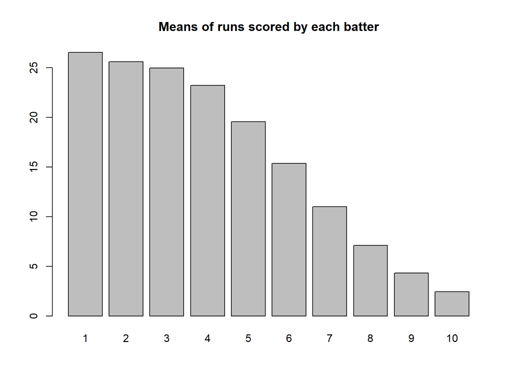

```r
barplot(runmeans, main="Means of runs scored by each batter",
        names.arg = 1:10)
```

# Results 2

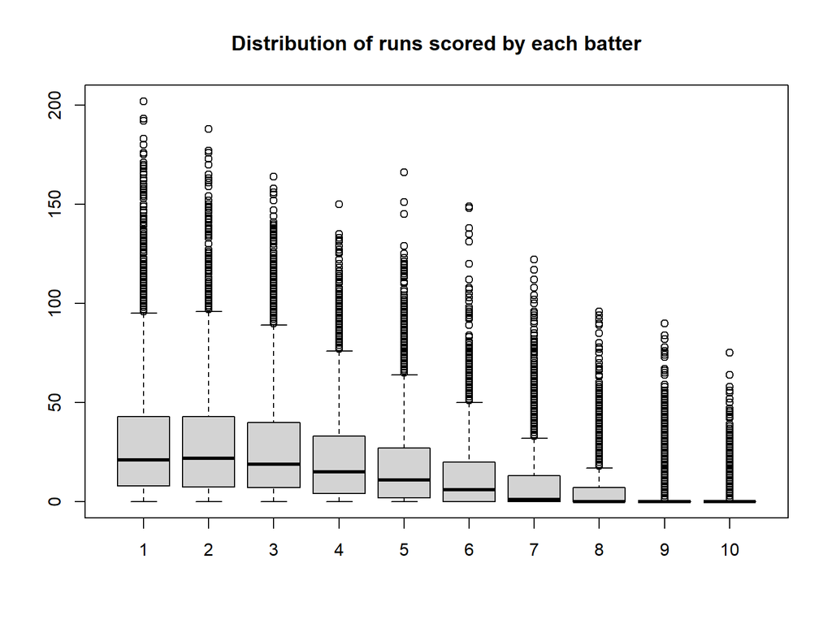

```r
boxplot(allsims_runs_batter, main="Distribution of runs scored by each batter")
```

# Results 2

The distribution of both would be this…

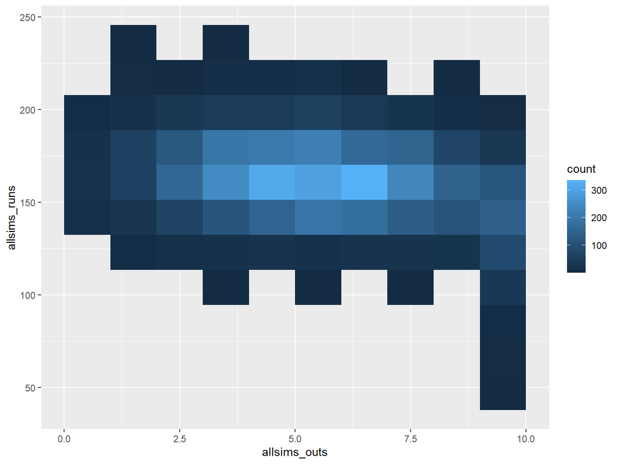

```r
ro = data.frame(allsims_runs, allsims_outs)

ggplot(ro, aes(x=allsims_outs, y=allsims_runs) ) +
  geom_bin2d(bins=10)
```

# Results vs. Real

How do we check how real any of this is?

Let’s look at our training data, and see how well our simulation fits it.

```r
head(gamelog)
```

```
##   Format MatchNo TeamBowling TeamBatting Inning Over Ball Bowler BowlerID
## 1   T20I      33         AUS          BD      1    0    1  B Lee       17
## 2   T20I      33         AUS          BD      1    0    2  B Lee       17
## 3   T20I      33         AUS          BD      1    0    3  B Lee       17
## 4   T20I      33         AUS          BD      1    0    4  B Lee       17
## 5   T20I      33         AUS          BD      1    0    4  B Lee       17
## 6   T20I      33         AUS          BD      1    0    5  B Lee       17
##       Batsman BatsmanID Fielder FielderID Outcome NumOutcome BallType
## 1 Tamim Iqbal      1041                NA      no          0      run
## 2 Tamim Iqbal      1041                NA      no          0      run
## 3 Tamim Iqbal      1041                NA      no          0      run
## 4 Tamim Iqbal      1041                NA       1          1     wide
## 5 Tamim Iqbal      1041                NA      no          0      run
## 6 Tamim Iqbal      1041                NA      no          0      run
##   NumBallType  Notes
```

[output cut: 20 more lines]

# Results vs. Real

“Means of runs scored by each batter”

```r
# Real
runs_by_wicket <- gamelog %>%
        group_by(Wickets) %>%
        summarise(matches = length(unique(MatchNo)),
                  total_runs = sum(pmax(NumOutcome, 0), na.rm=FALSE))


runs_by_wicket$mean_runs = runs_by_wicket$total_runs / runs_by_wicket$matches[1]
runs_by_wicket$sim1 = runmeans
runs_by_wicket$sim2 = runmeans2

runs_by_wicket
```

```
## # A tibble: 10 × 6
##    Wickets matches total_runs mean_runs  sim1  sim2
##      <int>   <int>      <dbl>     <dbl> <dbl> <dbl>
##  1       0     688      22534     32.8  26.6  30.9
##  2       1     688      21657     31.5  25.6  30.1
##  3       2     682      20419     29.7  25.0  27.0
##  4       3     661      18008     26.2  23.2  22.5
##  5       4     606      13554     19.7  19.6  18.4
##  6       5     516       9056     13.2  15.4  13.4
##  7       6     384       5336      7.76 11.0   9.05
##  8       7     261       3210      4.67  7.13  5.70
##  9       8     150       1551      2.25  4.34  3.10
## 10       9      87        974      1.42  2.45  1.62
```

# Next steps

- Incorporate actual player effects
  - (This is more difficult than in baseball because of partnerships)
- Find ways to simulate strategic play (managing numbers of wickets remaining)
- Find ways to simulate strategic play in the second innings.
- Much, much better visualizations